# Lecture 321

2021-09-11

## Simple Regression

## Recap

**Prev**: Comparing data

- 311 Lecture Comparing groups
- 312 Lecture Correlation
- 313 Lecture Data transformations
- 314 Practical session

**Now**: Simple Regression

- Regression
- Ordinary Least Squares
- Interpretation
- Checking assumptions

## Regression analysis

**Regression analysis** is a supervised machine learning approach

Special case of the general linear model

\[outcome_i = (model) + error_i \]

Predict (estimate) value of one outcome (dependent) variable as

- one predictor (independent) variable: **simple / univariate**

\[Y_i = (b_0 + b_1 * X_{i1}) + \epsilon_i \]

- more predictor (independent) variables: **multiple / multivar.**

\[Y_i = (b_0 + b_1 * X_{i1} + b_2 * X_{i2} + \dots + b_M * X_{iM}) + \epsilon_i \]

## Example

Can we predict a penguin’s body mass from flipper length?

\[body\ mass_i = (b_0 + b_1 * flipper\ length_{i}) + \epsilon_i \]

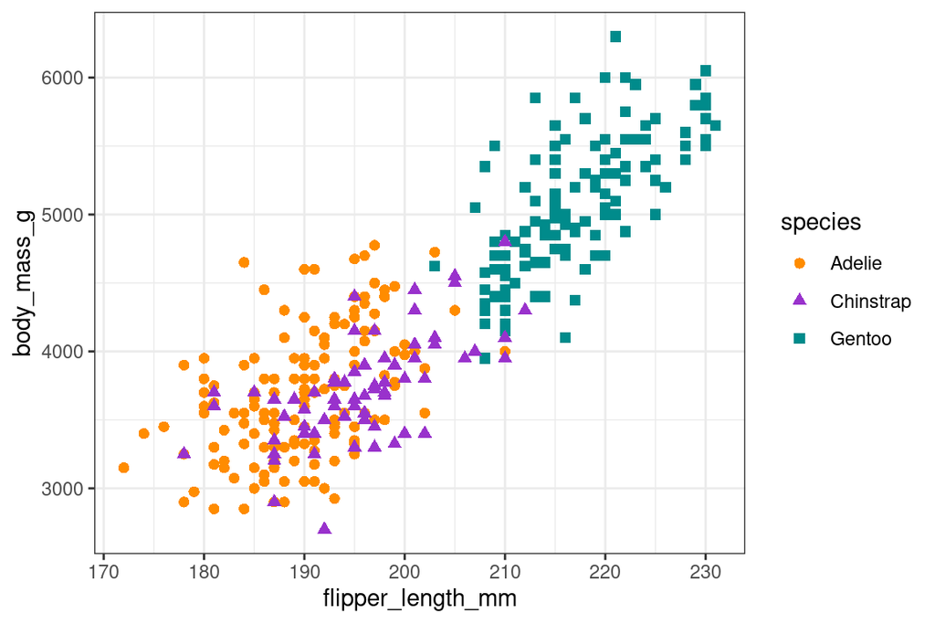

## Example

Can we predict a penguin’s body mass from flipper length?

\[body\ mass_i = (b_0 + b_1 * flipper\ length_{i}) + \epsilon_i \]

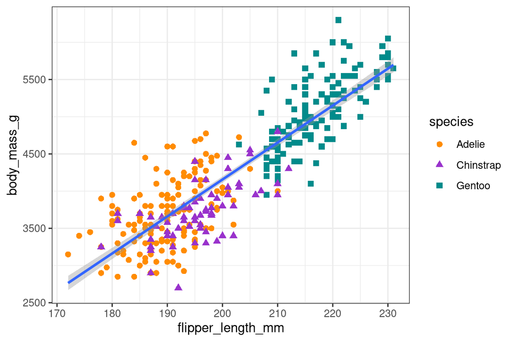

## Least squares

**Least squares** is the most commonly used approach to generate a regression model

The model fits a line

- to **minimise** the squared values of the **residuals** (errors)
- that is squared difference between
  - **observed values**
  - **model**

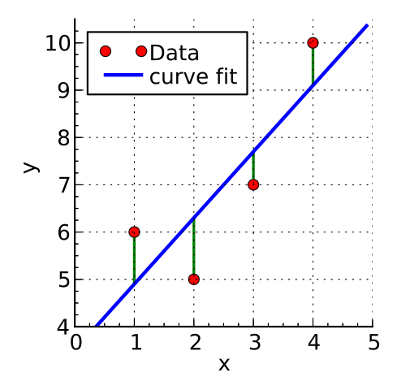

by Krishnavedala  
via Wikimedia Commons,  
CC-BY-SA-3.0

\[residual_i = observed_i - model_i\] \[deviation = \sum_i(observed_i - model_i)^2\]

## Assumptions

- **Linearity**
  - the relationship is actually linear
- **Normality** of residuals
  - standard residuals are normally distributed with mean `0`
- **Homoscedasticity** of residuals
  - at each level of the predictor variable(s) the variance of the standard residuals should be the same (*homo-scedasticity*) rather than different (*hetero-scedasticity*)
- **Independence** of residuals
  - adjacent standard residuals are not correlated

## stats::lm

```r
bm_fl_model <-
  palmerpenguins::penguins %>%
  dplyr::filter(!is.na(body_mass_g) | !is.na(flipper_length_mm)) %$%
  stats::lm(body_mass_g ~ flipper_length_mm)

bm_fl_model %>%
  summary()
```

```
##
## Call:
## stats::lm(formula = body_mass_g ~ flipper_length_mm)
##
## Residuals:
##      Min       1Q   Median       3Q      Max
## -1058.80  -259.27   -26.88   247.33  1288.69
##
## Coefficients:
##                    Estimate Std. Error t value Pr(>|t|)
## (Intercept)       -5780.831    305.815  -18.90   <2e-16 ***
## flipper_length_mm    49.686      1.518   32.72   <2e-16 ***
## ---
## Signif. codes:  0 '***' 0.001 '**' 0.01 '*' 0.05 '.' 0.1 ' ' 1
##
## Residual standard error: 394.3 on 340 degrees of freedom
## Multiple R-squared:  0.759,  Adjusted R-squared:  0.7583
## F-statistic:  1071 on 1 and 340 DF,  p-value: < 2.2e-16
```

## Overall fit

The output indicates

- **p-value: < 2.2e-16**: \(p<.01\) the model is significant
  - derived by comparing **F-statistic** (1070.74) to F distribution having specified degrees of freedom (1, 340)
  - Report as: F(1, 340) = 1070.74
- **Adjusted R-squared: 0.7583**:
  - flipper length can account for 75.83% variation in body mass
- **Coefficients**
  - Intercept estimate -5780.8314 is significant
  - `flipper_length_mm` (slope) estimate 49.6856 is significant

## Outliers and influential cases

```r
penguins_output <-
  palmerpenguins::penguins %>%
  dplyr::filter(!is.na(body_mass_g) | !is.na(flipper_length_mm)) %>%
  mutate(
    model_stdres = bm_fl_model %>% stats::rstandard(),
    model_cook_dist = bm_fl_model %>% stats::cooks.distance()
  )

penguins_output %>%
  dplyr::select(body_mass_g, model_stdres, model_cook_dist) %>%
  dplyr::filter(abs(model_stdres) > 2.58 | model_cook_dist > 1)
```

```
## # A tibble: 4 × 3
##   body_mass_g model_stdres model_cook_dist
##         <int>        <dbl>           <dbl>
## 1        4650         3.28          0.0388
## 2        5850         2.66          0.0182
## 3        6300         2.80          0.0353
## 4        2700        -2.69          0.0149
```

No influential cases (Cook’s distance `> 1`) but there are a handful of outliers (4 abs std res `> 2.58`)

## Checking assumptions: normality

Shapiro-Wilk test for normality of standard residuals,

- robust models: should be **not** significant

```r
penguins_output %$%
  stats::shapiro.test(
    model_stdres
  )
```

```
##
##  Shapiro-Wilk normality test
##
## data:  model_stdres
## W = 0.99295, p-value = 0.1085
```

**Standard residuals are normally distributed!**

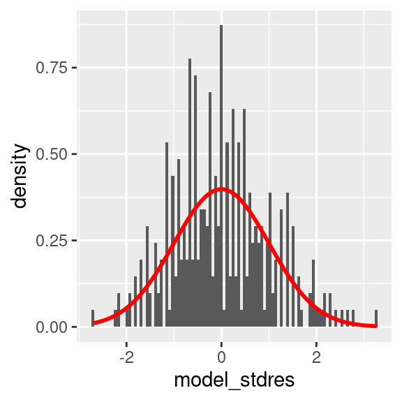

## Checking assumpt.: homoscedasticity

Breusch-Pagan test for homoscedasticity of standard residuals

- robust models: should be **not** significant

```r
bm_fl_model %>%
  lmtest::bptest()
```

```
##
##  studentized Breusch-Pagan test
##
## data:  .
## BP = 2.1579, df = 1, p-value = 0.1418
```

**Standard residuals are homoscedastic!**

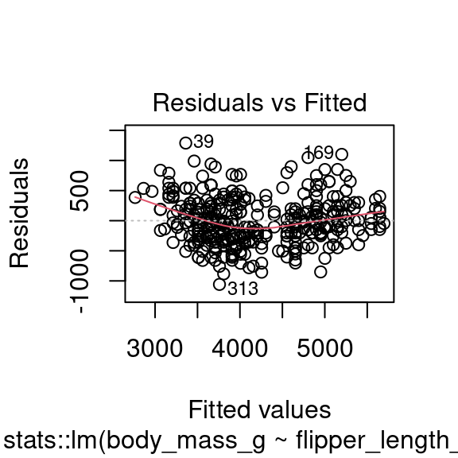

## Checking assumptions: independence

Durbin-Watson test for the independence of residuals

- robust models: statistic should be close to 2 (advised between 1 and 3) and **not** significant

```r
bm_fl_model %>%
  lmtest::dwtest()
```

```
##
##  Durbin-Watson test
##
## data:  .
## DW = 2.1896, p-value = 0.9572
## alternative hypothesis: true autocorrelation is greater than 0
```

**Standard residuals are independent!**

Note: the result depends on the order of the data.

## Example

Yes, we can predict a penguin’s body mass from flipper length!

\[body\ mass_i = (-5780.83 + 49.69 * flipper\ length_{i}) + \epsilon_i \]

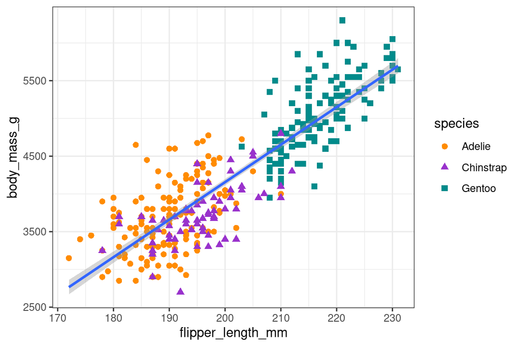

## Summary

Simple Regression

- Regression
- Ordinary Least Squares
- Interpretation
- Checking assumptions

**Next**: Multiple Regression

- Multiple regression
- Interpretation
- Checking assumptions